# MATH 189 Homework 3

Weixiu Dong, Mengheng Yang, Xuqian Tan, Yushan Liu, Iris Ziyi Wang

1/24/2020

## Dataset Description

*Reference:*  
An exploratory data analysis on airbnb listings in NYC in 2019 Raw dataset source: https://www.kaggle.com/dgomonov/new-york-city-airbnb-open-data

```
##  [1] "id"                             "name"
##  [3] "host_id"                        "host_name"
##  [5] "neighbourhood_group"            "neighbourhood"
##  [7] "latitude"                       "longitude"
##  [9] "room_type"                      "price"
## [11] "minimum_nights"                 "number_of_reviews"
## [13] "last_review"                    "reviews_per_month"
## [15] "calculated_host_listings_count" "availability_365"
```

```
## [1] 48895    16
```

|  | id | name | host_id | host_name | neighbourhood_group | neighbourhood | latitude | longitude | room_type | price | minimum_nights | number_of_reviews | last_review | reviews_per_month | calculated_host_listings_count | availability_365 |
| --- | --- | --- | --- | --- | --- | --- | --- | --- | --- | --- | --- | --- | --- | --- | --- | --- |
| 1 | 2539 | Clean & quiet apt home by the park | 2787 | John | Brooklyn | Kensington | 40.64749 | -73.97237 | Private room | 149 | 1 | 9 | 2018-10-19 | 0.21 | 6 | 365 |
| 2 | 2595 | Skylit Midtown Castle | 2845 | Jennifer | Manhattan | Midtown | 40.75362 | -73.98377 | Entire home/apt | 225 | 1 | 45 | 2019-05-21 | 0.38 | 2 | 355 |
| 3 | 3647 | THE VILLAGE OF HARLEM....NEW YORK ! | 4632 | Elisabeth | Manhattan | Harlem | 40.80902 | -73.94190 | Private room | 150 | 3 | 0 |  | NA | 1 | 365 |
| 4 | 3831 | Cozy Entire Floor of Brownstone | 4869 | LisaRoxanne | Brooklyn | Clinton Hill | 40.68514 | -73.95976 | Entire home/apt | 89 | 1 | 270 | 2019-07-05 | 4.64 | 1 | 194 |
| 5 | 5022 | Entire Apt: Spacious Studio/Loft by central park | 7192 | Laura | Manhattan | East Harlem | 40.79851 | -73.94399 | Entire home/apt | 80 | 10 | 9 | 2018-11-19 | 0.10 | 1 | 0 |
| 6 | 5099 | Large Cozy 1 BR Apartment In Midtown East | 7322 | Chris | Manhattan | Murray Hill | 40.74767 | -73.97500 | Entire home/apt | 200 | 3 | 74 | 2019-06-22 | 0.59 | 1 | 129 |

There are 16 variables (with explanations):  
1. Id (listing ID),  
2. name (name of the listing),  
3. host_id (host ID),  
4. host_name (name of the host),  
5. neighbourhood_group (location),  
6. neighbourhood (area),  
7. latitude (latitude coordinates),  
8. longitude (longitude coordinates),  
9. room_type (listing space type),  
10. price (price in dollars),  
11. minimum_nights (amount of nights minimum),  
12. number_of_reviews (number of reviews),  
13. last_review (latest review),  
14. reviews_per_month (number of reviews per month),  
15. calculated_host_listings_count (amount of listing per host),  
16. availability_365 (number of days when listing is available for booking)

## Research Question

### What factors would affect the popularity of different room types？

## Data Cleaning

Based on our research question, we will group my data with room types.  
There are 3 different categories for room type: **Private room**, **Entire home/apt** and **Shared room**.

```
## Entire home/apt    Private room     Shared room
##           25409           22326            1160
```

Let’s keep only relevant columns for our research question.

```
## [1] "neighbourhood_group" "room_type"           "price"
## [4] "minimum_nights"      "number_of_reviews"   "availability_365"
```

```
## [1] 48895     6
```

|  | neighbourhood_group | room_type | price | minimum_nights | number_of_reviews | availability_365 |
| --- | --- | --- | --- | --- | --- | --- |
| 1 | Brooklyn | Private room | 149 | 1 | 9 | 365 |
| 2 | Manhattan | Entire home/apt | 225 | 1 | 45 | 355 |
| 3 | Manhattan | Private room | 150 | 3 | 0 | 365 |
| 4 | Brooklyn | Entire home/apt | 89 | 1 | 270 | 194 |
| 5 | Manhattan | Entire home/apt | 80 | 10 | 9 | 0 |
| 6 | Manhattan | Entire home/apt | 200 | 3 | 74 | 129 |

Check if there’s any NA in the dataset.

```
## [1] 0
```

Cleaning **availability_365**: remove all rows with value of 0.

## Table 1

|  | Entire home/apt (n=16533) | Private room (n=13965) | Shared room (n=864) | Overall (n=31362) |
| --- | --- | --- | --- | --- |
| neighbourhood_group |  |  |  |  |
| Bronx | 318 (1.9%) | 546 (3.9%) | 50 (5.8%) | 914 (2.9%) |
| Brooklyn | 6072 (36.7%) | 5880 (42.1%) | 308 (35.6%) | 12260 (39.1%) |
| Manhattan | 8441 (51.1%) | 4782 (34.2%) | 336 (38.9%) | 13559 (43.2%) |
| Queens | 1550 (9.4%) | 2586 (18.5%) | 162 (18.8%) | 4298 (13.7%) |
| Staten Island | 152 (0.9%) | 171 (1.2%) | 8 (0.9%) | 331 (1.1%) |
| price |  |  |  |  |
| Mean (SD) | 225 (298) | 93.9 (173) | 66.0 (97.8) | 162 (254) |
| Median [Min, Max] | 170 [0.00, 10000] | 70.0 [0.00, 10000] | 43.0 [0.00, 1800] | 112 [0.00, 10000] |
| minimum_nights |  |  |  |  |
| Mean (SD) | 10.4 (26.6) | 6.03 (18.7) | 7.02 (35.8) | 8.34 (23.8) |
| Median [Min, Max] | 3.00 [1.00, 1250] | 2.00 [1.00, 999] | 1.00 [1.00, 999] | 3.00 [1.00, 1250] |
| number_of_reviews |  |  |  |  |
| Mean (SD) | 31.0 (49.3) | 33.6 (54.9) | 19.1 (37.0) | 31.9 (51.6) |
| Median [Min, Max] | 9.00 [0.00, 488] | 12.0 [0.00, 629] | 5.00 [0.00, 454] | 10.0 [0.00, 629] |
| availability_365 |  |  |  |  |
| Mean (SD) | 172 (125) | 178 (127) | 218 (137) | 176 (126) |
| Median [Min, Max] | 168 [1.00, 365] | 164 [1.00, 365] | 253 [1.00, 365] | 168 [1.00, 365] |

## Data Visualization / Ploting

### Bar plots for categorical variables

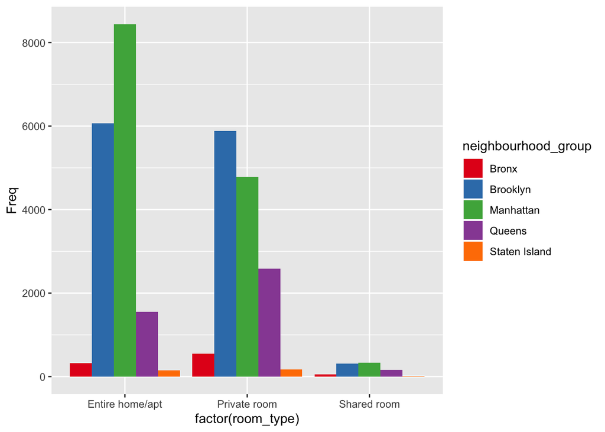

### Plots for continous variable

We first take a look at **availability_365**.

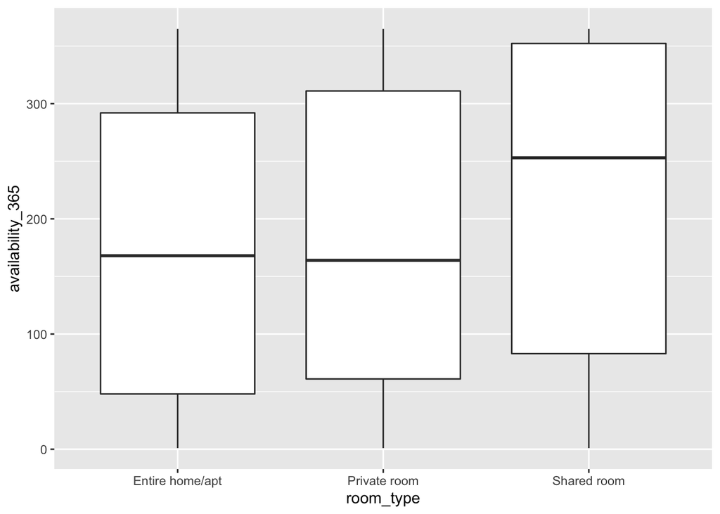

Then, we explore some variables with both boxplots and histgorams by groups. We notice that these data are highly skewed.

Let’s first take a look at **price** by groups.

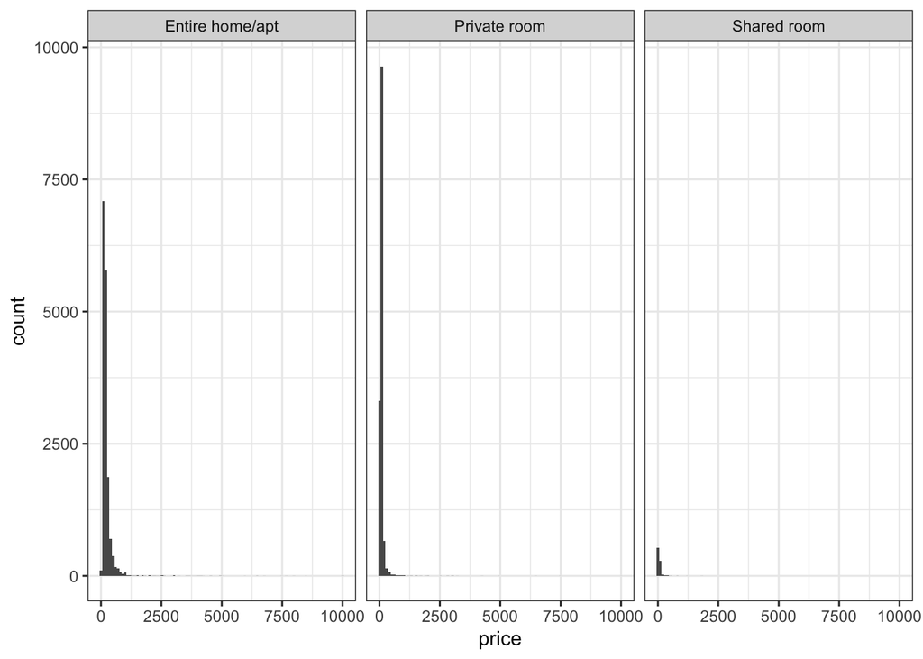

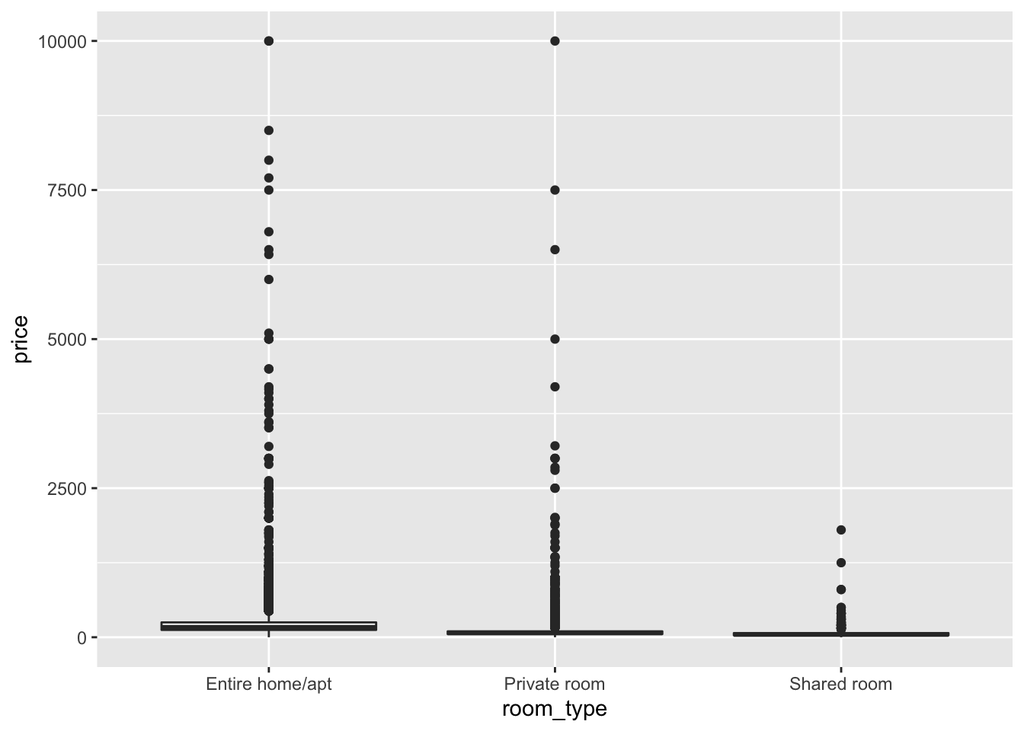

We decide to zoom in on **price** from the range *0-1000*.

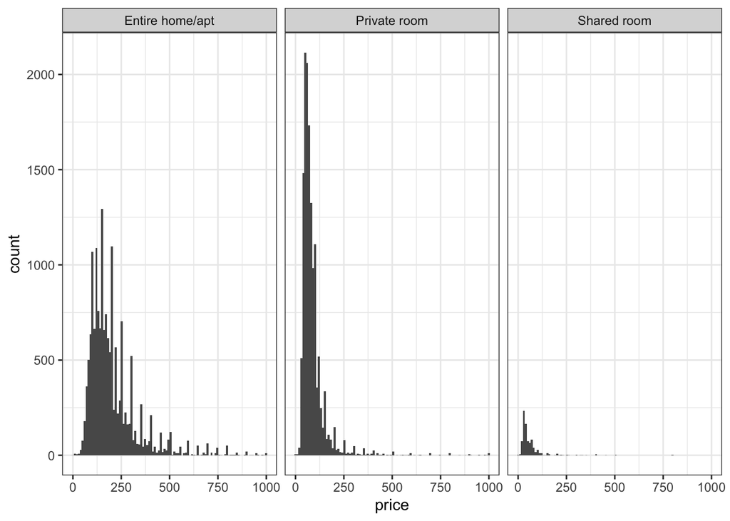

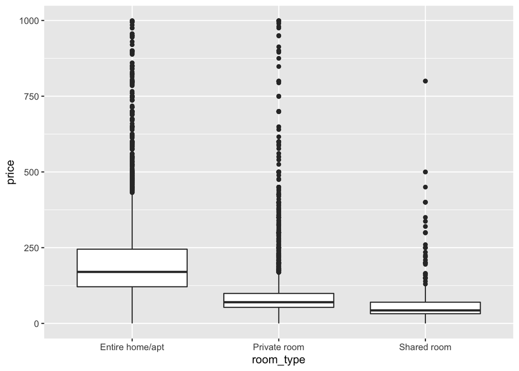

Then **minimum_nights**.

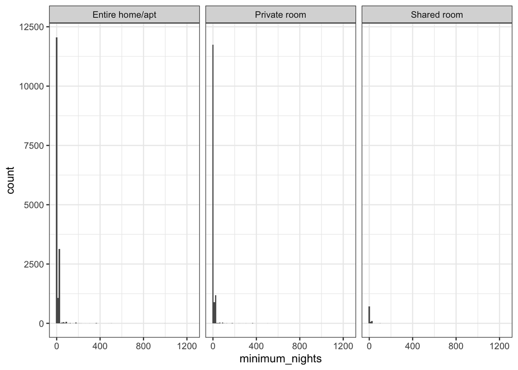

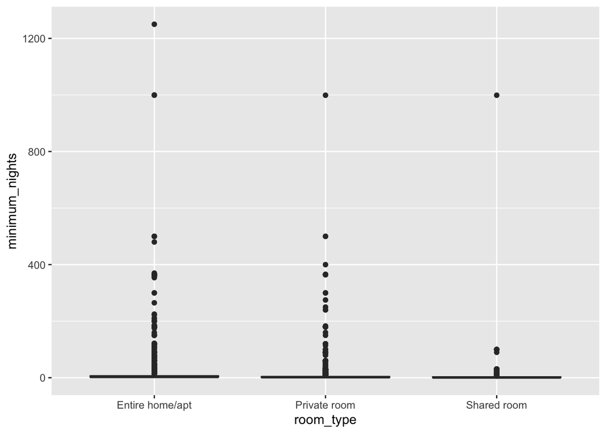

Since the data is highly skewed, we decide to zoom in on **minimum_nights** from the range *0-50*.

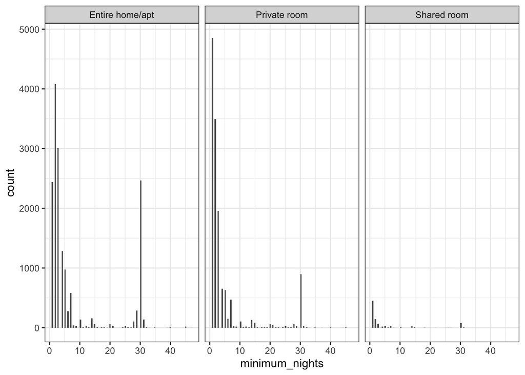

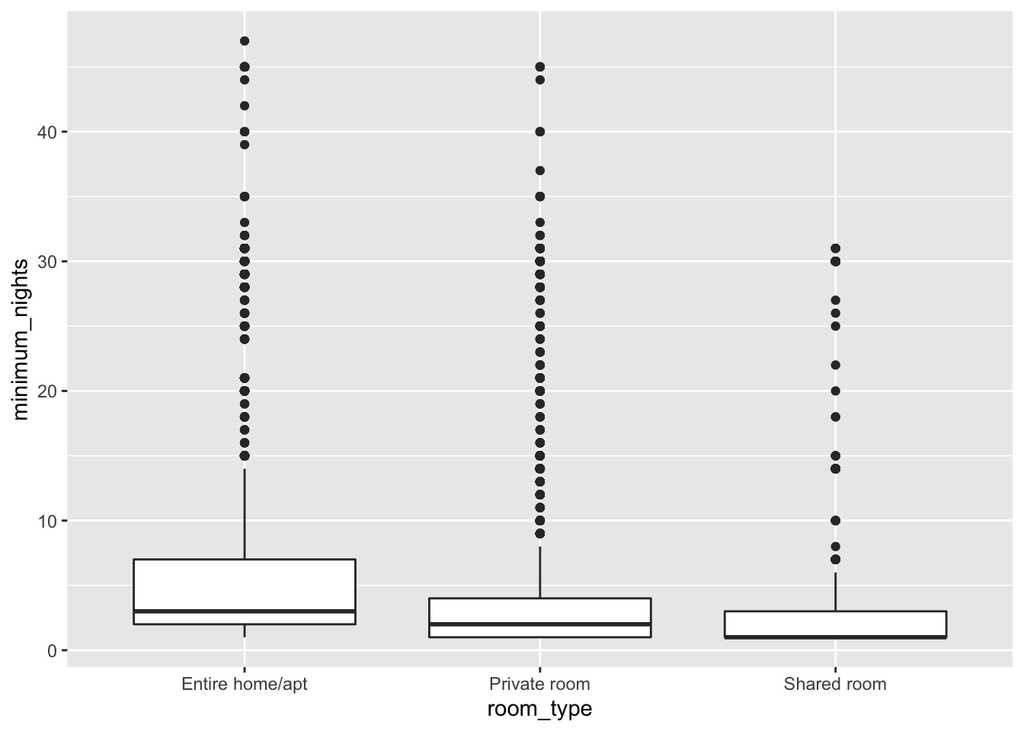

We notice that there is a small peak at 30 days, which makes sense for some hosts to start renting their house with a month as the minimum.

We can look into **number_of_review** by just investigating the histogram by groups.

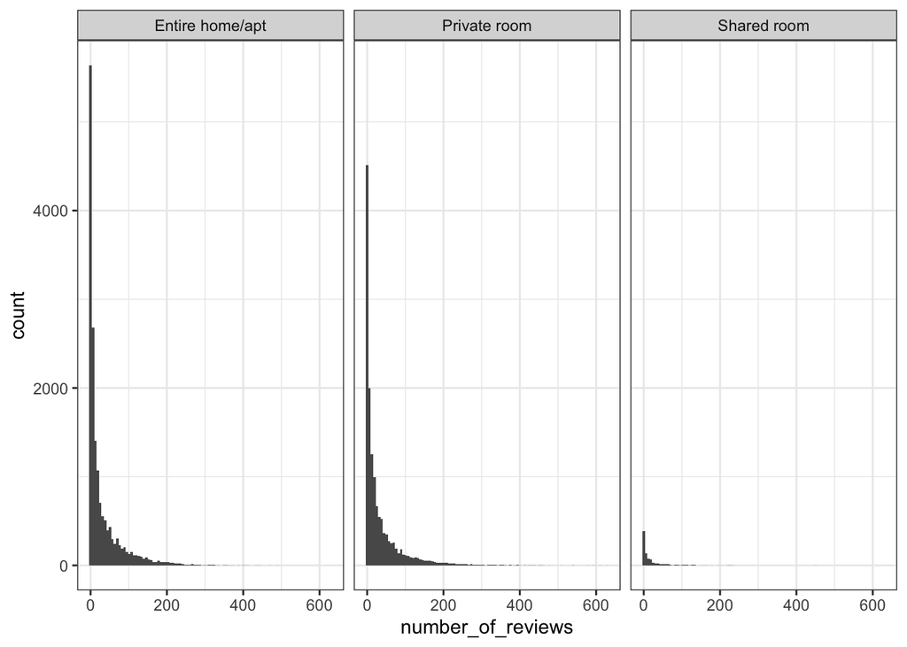

Attached R code:

```r
data <- read.csv('AB_NYC_2019.csv')

names(data)
dim(data)
head(data)


summary(as.factor(data$room_type))

keeps <- c('neighbourhood_group', 'room_type','price','minimum_nights', 'number_of_reviews','availability_365')
df = data[,names(data) %in% keeps]
names(df)
dim(df)
head(df)

sum(is.na(df))

df<-df[!(df$availability_365 ==0),]

library("table1")
table1(~ neighbourhood_group +
       price +
       minimum_nights +
       number_of_reviews +
       availability_365 | room_type,
       data=df)


#neighbourhood_group
library(ggplot2)
bar_tbl <- with(df, table(room_type, neighbourhood_group ))

ggplot(as.data.frame(bar_tbl), aes(x= factor(room_type), y = Freq , fill =neighbourhood_group)) +
  geom_bar(stat="identity", position = "dodge") +
  scale_fill_brewer(palette = "Set1")
```

```r
#avalability_365
ggplot(df, aes(x=room_type, y= availability_365)) +
    geom_boxplot()
```

```r
#price
ggplot(df,aes(x=price))+
    geom_histogram(bins = 100)+
    facet_grid(~room_type)+
    theme_bw()
```

```r
ggplot(df, aes(x=room_type, y=price)) +
    geom_boxplot()
```

```r
ggplot(df[df$price < 1000, ],aes(x=price))+
    geom_histogram(bins = 100)+
    facet_grid(~room_type)+
    theme_bw()
```

```r
ggplot(df[df$price < 1000, ], aes(x=room_type, y=price)) +
    geom_boxplot()
```

```r
# minimum_nights
ggplot(df,aes(x=minimum_nights))+
    geom_histogram(bins = 100)+
    facet_grid(~room_type)+
    theme_bw()
```

```r
ggplot(df, aes(x=room_type, y= minimum_nights)) +
    geom_boxplot()
```

```r
ggplot(df[df$minimum_nights < 50, ],aes(x=minimum_nights))+
    geom_histogram(bins = 100)+
    facet_grid(~room_type)+
    theme_bw()
```

```r
ggplot(df[df$minimum_nights < 50, ], aes(x=room_type, y= minimum_nights)) +
    geom_boxplot()
```

```r
# number_of_reviews
ggplot(df,aes(x=number_of_reviews))+
    geom_histogram(bins = 100)+
    facet_grid(~room_type)+
    theme_bw()
```